# Discrete and Continuous Named Distributions

Lesson 6 and 7

## Why learn named distributions?

A handful of situations come up so often that the PMF, mean, and variance have **already been worked out**.

Our job is to:

1. **Recognize** the situation
2. **Match** it to a named distribution
3. **Use the distribution** to compute probabilities, mean, and variance

Today we’re covering **discrete** named distributions.

## Bernoulli – a single success/failure trial

**What we are modeling**

One trial with two outcomes:

- $X = 1$ for a **success**, probability $p$
- $X = 0$ for a **failure**, probability $1-p$

**Support:** $x \in \{0, 1\}$ – two values only

**Parameter:** $p = P(\text{success})$

**PMF**

$$P(X = x) = p^{x}(1-p)^{1-x}$$

**Mean and variance**

$$\mu = p \qquad \sigma^2 = p(1-p)$$

**Examples**

- Make one free throw at $p = 0.7$
- Aircraft doesn’t break on one sortie at $p = 0.999$

**In R** – no `dbern()`; use the Binomial with `size = 1`

```r
dbinom(x, size = 1, prob = p)   # PMF: P(X = x)
pbinom(x, size = 1, prob = p)   # cdf: P(X <= x)
```

The **building block** for the other three distributions.

## Bernoulli – visualizing the PMF

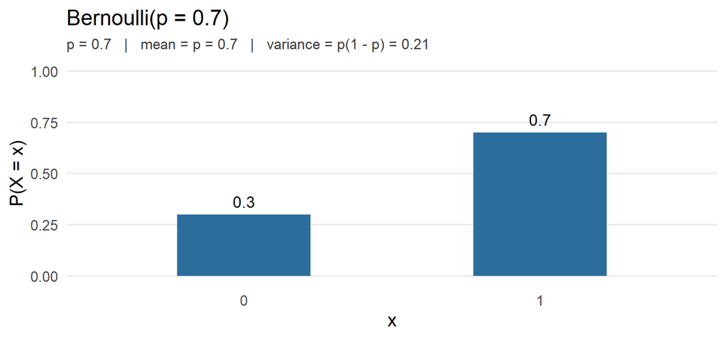

R has no `dbern()`. Use the Binomial with `size = 1`.

## Binomial – successes in $n$ fixed trials

**What we are modeling**

The **number of successes** in $n$ fixed trials.

**Support:** $k = 0, 1, \dots, n$ (bounded above by $n$)

**Parameters**:

- $n$ is fixed number of trials
- Each trial has $p=P(\text{success})$

**PMF**

$$P(X = k) = \binom{n}{k} p^{k}(1-p)^{n-k}$$

**Mean and variance**

$$\mu = np \qquad \sigma^2 = np(1-p)$$

**Examples**

- Number made free throws in 10 tries
- Number of sorties with a failure in 1000 sorties.

**In R**

```r
dbinom(k, size = n, prob = p)   # PMF: P(X = k)
pbinom(k, size = n, prob = p)   # cdf: P(X <= k)
```

## Binomial – visualizing the PMF

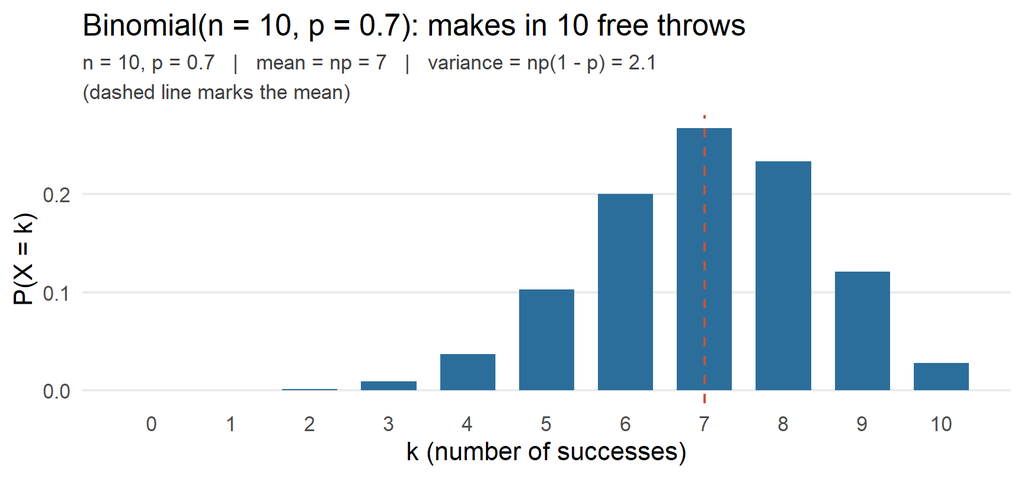

## Binomial using R

In order: $P(X = 6)$, $P(X \le 6)$, $P(X \ge 8)$, and the median.

```r
dbinom(6, size = 10, prob = 0.7)
```

```
[1] 0.2001209
```

```r
pbinom(6, size = 10, prob = 0.7)
```

```
[1] 0.3503893
```

```r
pbinom(7, size = 10, prob = 0.7, lower.tail = FALSE)
```

```
[1] 0.3827828
```

```r
qbinom(0.5, size = 10, prob = 0.7)
```

```
[1] 7
```

## Geometric – trials until 1st success

**What we are modeling**

The **number of trials until the first success**, counting the successful trial.

**Support:** $n = 1, 2, 3, \dots$ (unbounded above)

**Parameter:** $p = P(\text{success})$ on each trial

**PMF**

$$P(X = n) = (1-p)^{n-1}p$$

**Mean and variance**

$$\mu = \frac{1}{p} \qquad \sigma^2 = \frac{1-p}{p^2}$$

**Examples**

- Coin flips until the first heads
- Number free throws until first miss (or)

**In R** – shift by 1, since R counts *failures before* the first success

```r
dgeom(n - 1, prob = p)          # PMF: P(X = n)
pgeom(n - 1, prob = p)          # cdf: P(X <= n)
```

## Geometric – visualizing the PMF

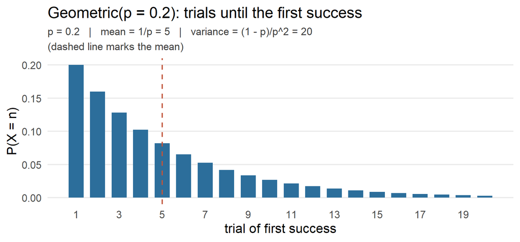

**In R,** `dgeom(x, p)` counts the **failures before** the first success, which is our trial number **minus 1**.

## Poisson – events in an interval

**What we are modeling**

**Counts of events** in a fixed interval, for a large population of independent events at a constant rate.

**Support:** $k = 0, 1, 2, \dots$ – **unbounded** above

**Parameter:** $\lambda$ = mean events per interval

**PMF**

$$P(X = k) = \frac{\lambda^{k}e^{-\lambda}}{k!}$$

**Mean and variance**

$$\mu = \lambda \qquad \sigma^2 = \lambda$$

**Examples**

- Cars through the North Gate per hour
- Typos on a page

**In R**

```r
dpois(k, lambda = lambda)       # PMF: P(X = k)
ppois(k, lambda = lambda)       # cdf: P(X <= k)
```

$\lambda$ is a **rate** – its unit must match the interval of $k$.

## Poisson – visualizing the PMF

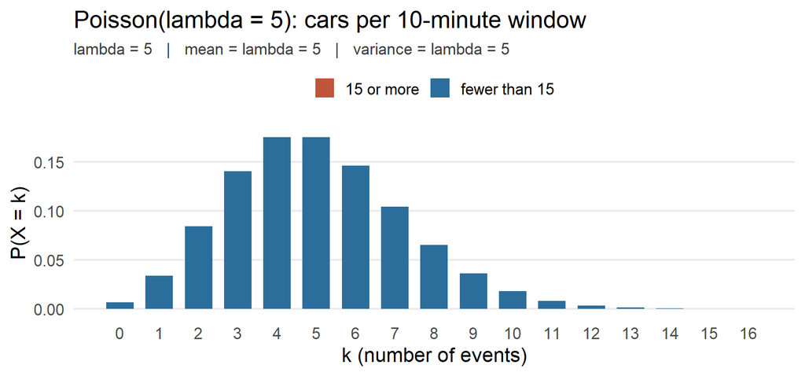

## Poisson using R

In order: $P(X = 5)$, $P(X \le 5)$, and $P(X \ge 15)$..

```r
dpois(5, lambda = 5)
```

```
[1] 0.1754674
```

```r
ppois(5, lambda = 5)
```

```
[1] 0.6159607
```

```r
1 - ppois(14, lambda = 5)
```

```
[1] 0.0002262537
```

## Choosing the right discrete distribution

| Situation | Distribution |
| --- | --- |
| One trial, success/failure | Bernoulli($p$) |
| Trials **until** the first success | Geometric($p$) |
| Successes in a **fixed** number $n$ of trials | Binomial($n, p$) |
| Counts of events in an interval | Poisson($\lambda$) |

## Functions in R

| Prefix | Returns | Example |
| --- | --- | --- |
| `d` | PMF, $P(X = x)$ | `dbinom(6, 10, 0.7)` |
| `p` | cdf, $P(X \le x)$ | `pbinom(6, 10, 0.7)` |
| `q` | quantile | `qbinom(0.5, 10, 0.7)` |
| `r` | random draws | `rbinom(10000, 10, 0.7)` |

# Continuous Named Distributions

## Discrete → Continuous: what changes?

Last lesson our variables **counted** things. Now they can take **any value in an interval** – so the rules shift:

- The PDF $f_X(x)$ gives the **height** of the curve, **not** a probability. Remember, for a continuous random variable, $f_X(x) \neq P(X = x)$.
- $P(X = \text{a single exact value}) = 0$ – a point has zero width.
- **Probabilities are areas:** $P(a \le X \le b)$ is the area under the curve between $a$ and $b$. The **total area under the curve is 1**.

## Uniform – equally likely

**What we are modeling**

A continuous random variable, $X$, where **all equal-length intervals** in $[a, b]$ are equally likely. The density is **flat** – draw it as a **rectangle**.

**Support:** $x \in [a, b]$

**Parameters:**

- $a$ = minimum, $b$ = maximum

**PDF**

$$f_X(x) = \frac{1}{b - a}, \quad a \le x \le b$$

**Mean and variance**

$$\mu = \frac{a + b}{2} \qquad \sigma^2 = \frac{(b - a)^2}{12}$$

**Examples**

- A plane lands between 1200 and 1400

**In R** – suffix `unif`, with `min` and `max`

```r
punif(x, min = a, max = b)      # cdf: P(X <= x)
qunif(p, min = a, max = b)      # quantile
```

## Uniform – visualizing the PDF

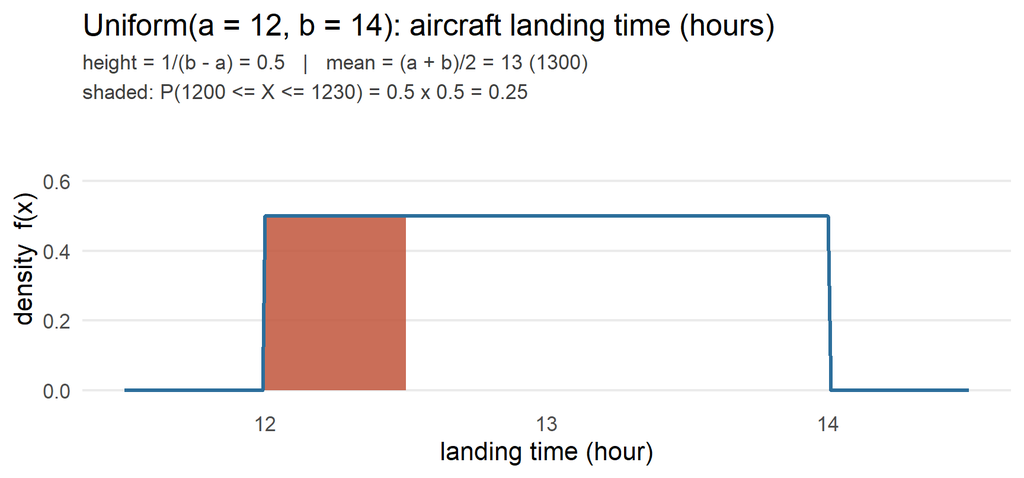

A probability is the **area of a rectangle**: width $\times$ height.

## Uniform using R

$P(X \le 12.5)$ (lands by 1230), then the expected landing time.

```r
punif(12.5, min = 12, max = 14)   # area: 0.5 wide x 0.5 tall
```

```
[1] 0.25
```

```r
(12 + 14) / 2                     # E(X) = (a + b)/2
```

```
[1] 13
```

## Normal/Gaussian – the bell curve

**What we are modeling**

A measurement that clusters **symmetrically** around a typical value, with values farther from the center progressively less likely.

Normal is defined by the **shape** (symmetric, bell-shaped).

**Support:** $x \in (-\infty, \infty)$

**Parameters:** mean $\mu$, standard deviation $\sigma$

**PDF** (we don’t compute by hand)

$$f_X(x) = \frac{1}{\sigma\sqrt{2\pi}}\, e^{-\frac{1}{2}\left(\frac{x - \mu}{\sigma}\right)^2}$$

**Mean and variance**

$$\mu = \mu \qquad \sigma^2 = \sigma^2$$

**Examples**

- PFT scores: $N(\mu=350, \sigma=40)$
- Cadet heights: $N(70, 10)$ inches

**In R** – suffix `norm`, with `mean` and `sd`

```r
pnorm(x, mean = mu, sd = sigma)   # cdf: P(X <= x)
qnorm(p, mean = mu, sd = sigma)   # quantile (percentile -> score)
```

## Z-scores – how unusual is a value?

Assuming $X \sim N(\mu, \sigma)$, let $Z$ be a defined as,

$$Z = \frac{x - \mu}{\sigma}.$$
Then $Z \sim N(\mu=0, \sigma=1)$, a **standard normal** distribution. The new random variable $Z$ represents how many standard deviations an observation of $X$ is from the mean.

**Example:** If $x_\text{pft}\sim N(350,40)$, then a PFT score $x_\text{pft}= 450$ has $Z_\text{pft} = (450 - 350)/40 = 2.5$.

The larger $|Z|$, the more **unusual** the observation since its “farther” from the mean. The **Empirical Rule** gives us the probability that $Z$ will lie with 1, 2, and 3 standard deviations of the mean.

| Region | P(Z in region) |
| --- | --- |
| $-1 < Z < 1 \text{ (or }\mu\pm1\sigma\text{)}$ | 0.68 |
| $-2 < Z < 2 \text{ (or }\mu\pm2\sigma\text{)}$ | 0.95 |
| $-3 < Z < 3 \text{ (or }\mu\pm3\sigma\text{)}$ | 0.997 |

## The Empirical Rule (68–95–99.7)

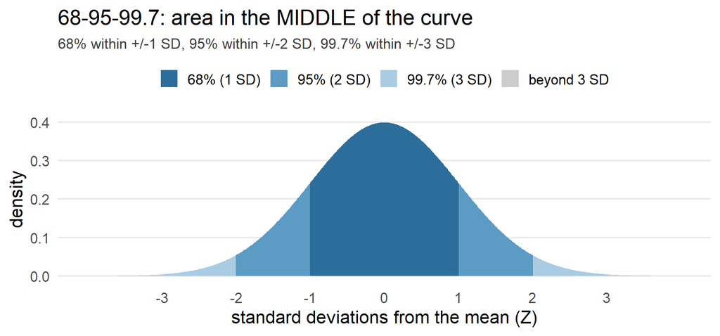

## Normal using R

Assuming PFT scores are $N(\mu = 350, \sigma = 40)$:

```r
(450 - 350) / 40                                  # Z-score of a 450
```

```
[1] 2.5
```

```r
1 - pnorm(450, mean = 350, sd = 40)               # P(score > 450)
```

```
[1] 0.006209665
```

```r
1 - pnorm(2.5, mean = 0, sd = 1)                  # P(Z_score > 2.5) = P(score > 450)
```

```
[1] 0.006209665
```

```r
pnorm(300, mean = 350, sd = 40)                   # percentile of a 300
```

```
[1] 0.1056498
```

```r
qnorm(0.85, mean = 350, sd = 40)                  # top 15% cutoff (85th pctile)
```

```
[1] 391.4573
```

## Exponential – time until next event

**What we are modeling**

The **time, $Y$, until the next arrival/event** in a Poisson process. Or, equivalently, the time between consecutive arrivals/events.

**Support:** $y \ge 0$

**Parameter:** rate $\lambda$ – the **same** $\lambda$ as the Poisson (Note: Match the **time units** of $\lambda$ to the question.)

**PDF**

$$f_Y(y) = \lambda e^{-\lambda y}, \quad y \ge 0$$

**Mean and variance**

$$\mu = \frac{1}{\lambda} \qquad \sigma^2 = \frac{1}{\lambda^2}$$

**Examples**

- Time until the next customer at Subway
- Time until the next car passes the North Gate

**In R** – suffix `exp`, with `rate`

```r
pexp(y, rate = lambda)          # cdf: P(Y <= y)
qexp(p, rate = lambda)          # quantile
```

## Exponential vs. Geometric vs. Poisson

The Exponential is the **continuous cousin of the Geometric**:

| Distribution | Counts / measures | Type |
| --- | --- | --- |
| **Geometric** | number of **trials** until the first success | discrete |
| **Exponential** | continuous **time** until the next arrival | continuous |
| **Poisson** | number of **events** in a fixed interval | discrete |

- **Geometric** – we know the probability of an individual cadet getting sick
- **Poisson / Exponential** – we know the average **rate** of cadets getting sick. Poisson **counts** events per interval; Exponential is the **time between** them

## Exponential – visualizing the PDF

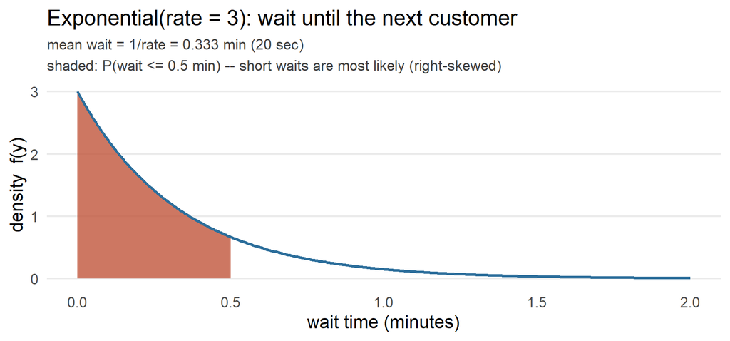

## Exponential using R

Customers arrive at rate $\lambda = 3$ per minute.

```r
1 / 3                         # E(wait) = 1/lambda minutes
```

```
[1] 0.3333333
```

```r
pexp(0.5, rate = 3)           # P(Y <= 0.5): area under the curve up to 0.5
```

```
[1] 0.7768698
```

## Choosing the right continuous distribution

| Situation | Distribution |
| --- | --- |
| All values in $[a, b]$ equally likely | Uniform($a, b$) |
| Measurement clustering symmetrically around a center | Normal($\mu, \sigma$) |
| **Time until** the next arrival (Poisson process) | Exponential($\lambda$) |

Recognize the situation and identify the distribution that best models the random variable.

## Functions in R

Same `d` / `p` / `q` / `r` pattern; the **suffix** names the distribution (`unif`, `norm`, `exp`).

| Prefix | Returns | Example |
| --- | --- | --- |
| `d` | density (**height**, NOT a probability for continuous variables) | `dnorm(350, 350, 40)` |
| `p` | cdf, $P(X \le x)$ | `pnorm(450, 350, 40)` |
| `q` | quantile (percentile → value) | `qnorm(0.85, 350, 40)` |
| `r` | random draws | `rnorm(10000, 350, 40)` |

**NOTE:** for continuous RVs we rarely use `d___()` except to **draw the curve** – the height is not a probability.